# Risk Factor Analysis

## Outcome Variable

**Outcome Variable:** pers_wast

## Predictor Variables

**Intervention Variable:** fage

**Adjustment Set:**

- arm
- W_mage
- meducyrs
- feducyrs
- W_mhtcm
- W_mwtkg
- W_mbmi
- W_fhtcm
- single
- brthmon
- delta_W_mage
- delta_meducyrs
- delta_feducyrs
- delta_W_mhtcm
- delta_W_mwtkg
- delta_W_mbmi
- delta_W_fhtcm
- delta_single
- delta_brthmon

## Stratifying Variables

The analysis was stratified on these variable(s):

- agecat
- studyid
- country

## Data Summary

| agecat | studyid | country | fage | pers_wast | n_cell | n |
| --- | --- | --- | --- | --- | --- | --- |
| 0-24 months | ki0047075b-MAL-ED | BANGLADESH | >=38 | 0 | 65 | 151 |
| 0-24 months | ki0047075b-MAL-ED | BANGLADESH | >=38 | 1 | 4 | 151 |
| 0-24 months | ki0047075b-MAL-ED | BANGLADESH | <32 | 0 | 30 | 151 |
| 0-24 months | ki0047075b-MAL-ED | BANGLADESH | <32 | 1 | 0 | 151 |
| 0-24 months | ki0047075b-MAL-ED | BANGLADESH | [32-38) | 0 | 49 | 151 |
| 0-24 months | ki0047075b-MAL-ED | BANGLADESH | [32-38) | 1 | 3 | 151 |
| 0-24 months | ki0047075b-MAL-ED | BRAZIL | >=38 | 0 | 30 | 79 |
| 0-24 months | ki0047075b-MAL-ED | BRAZIL | >=38 | 1 | 0 | 79 |
| 0-24 months | ki0047075b-MAL-ED | BRAZIL | <32 | 0 | 18 | 79 |
| 0-24 months | ki0047075b-MAL-ED | BRAZIL | <32 | 1 | 0 | 79 |
| 0-24 months | ki0047075b-MAL-ED | BRAZIL | [32-38) | 0 | 30 | 79 |
| 0-24 months | ki0047075b-MAL-ED | BRAZIL | [32-38) | 1 | 1 | 79 |
| 0-24 months | ki0047075b-MAL-ED | INDIA | >=38 | 0 | 36 | 161 |
| 0-24 months | ki0047075b-MAL-ED | INDIA | >=38 | 1 | 0 | 161 |
| 0-24 months | ki0047075b-MAL-ED | INDIA | <32 | 0 | 46 | 161 |
| 0-24 months | ki0047075b-MAL-ED | INDIA | <32 | 1 | 7 | 161 |
| 0-24 months | ki0047075b-MAL-ED | INDIA | [32-38) | 0 | 66 | 161 |
| 0-24 months | ki0047075b-MAL-ED | INDIA | [32-38) | 1 | 6 | 161 |
| 0-24 months | ki0047075b-MAL-ED | NEPAL | >=38 | 0 | 17 | 79 |
| 0-24 months | ki0047075b-MAL-ED | NEPAL | >=38 | 1 | 0 | 79 |
| 0-24 months | ki0047075b-MAL-ED | NEPAL | <32 | 0 | 14 | 79 |
| 0-24 months | ki0047075b-MAL-ED | NEPAL | <32 | 1 | 1 | 79 |
| 0-24 months | ki0047075b-MAL-ED | NEPAL | [32-38) | 0 | 47 | 79 |
| 0-24 months | ki0047075b-MAL-ED | NEPAL | [32-38) | 1 | 0 | 79 |
| 0-24 months | ki0047075b-MAL-ED | PERU | >=38 | 0 | 27 | 84 |
| 0-24 months | ki0047075b-MAL-ED | PERU | >=38 | 1 | 0 | 84 |
| 0-24 months | ki0047075b-MAL-ED | PERU | <32 | 0 | 28 | 84 |
| 0-24 months | ki0047075b-MAL-ED | PERU | <32 | 1 | 1 | 84 |
| 0-24 months | ki0047075b-MAL-ED | PERU | [32-38) | 0 | 28 | 84 |
| 0-24 months | ki0047075b-MAL-ED | PERU | [32-38) | 1 | 0 | 84 |

[output cut: 180 more lines]

The following strata were considered:

- agecat: 0-24 months, studyid: ki0047075b-MAL-ED, country: BANGLADESH
- agecat: 0-24 months, studyid: ki0047075b-MAL-ED, country: BRAZIL
- agecat: 0-24 months, studyid: ki0047075b-MAL-ED, country: INDIA
- agecat: 0-24 months, studyid: ki0047075b-MAL-ED, country: NEPAL
- agecat: 0-24 months, studyid: ki0047075b-MAL-ED, country: PERU
- agecat: 0-24 months, studyid: ki0047075b-MAL-ED, country: SOUTH AFRICA
- agecat: 0-24 months, studyid: ki0047075b-MAL-ED, country: TANZANIA, UNITED REPUBLIC OF
- agecat: 0-24 months, studyid: ki1000304b-SAS-CompFeed, country: INDIA
- agecat: 0-24 months, studyid: ki1000304b-SAS-FoodSuppl, country: INDIA
- agecat: 0-24 months, studyid: ki1119695-PROBIT, country: BELARUS
- agecat: 0-24 months, studyid: ki1135781-COHORTS, country: GUATEMALA
- agecat: 0-24 months, studyid: ki1135781-COHORTS, country: PHILIPPINES
- agecat: 0-24 months, studyid: ki1148112-LCNI-5, country: MALAWI
- agecat: 0-6 months, studyid: ki0047075b-MAL-ED, country: BANGLADESH
- agecat: 0-6 months, studyid: ki0047075b-MAL-ED, country: BRAZIL
- agecat: 0-6 months, studyid: ki0047075b-MAL-ED, country: INDIA
- agecat: 0-6 months, studyid: ki0047075b-MAL-ED, country: NEPAL
- agecat: 0-6 months, studyid: ki0047075b-MAL-ED, country: PERU
- agecat: 0-6 months, studyid: ki0047075b-MAL-ED, country: SOUTH AFRICA
- agecat: 0-6 months, studyid: ki0047075b-MAL-ED, country: TANZANIA, UNITED REPUBLIC OF
- agecat: 0-6 months, studyid: ki1119695-PROBIT, country: BELARUS
- agecat: 0-6 months, studyid: ki1135781-COHORTS, country: PHILIPPINES
- agecat: 6-24 months, studyid: ki0047075b-MAL-ED, country: BANGLADESH
- agecat: 6-24 months, studyid: ki0047075b-MAL-ED, country: BRAZIL
- agecat: 6-24 months, studyid: ki0047075b-MAL-ED, country: INDIA
- agecat: 6-24 months, studyid: ki0047075b-MAL-ED, country: NEPAL
- agecat: 6-24 months, studyid: ki0047075b-MAL-ED, country: PERU
- agecat: 6-24 months, studyid: ki0047075b-MAL-ED, country: SOUTH AFRICA
- agecat: 6-24 months, studyid: ki0047075b-MAL-ED, country: TANZANIA, UNITED REPUBLIC OF
- agecat: 6-24 months, studyid: ki1000304b-SAS-CompFeed, country: INDIA
- agecat: 6-24 months, studyid: ki1000304b-SAS-FoodSuppl, country: INDIA
- agecat: 6-24 months, studyid: ki1119695-PROBIT, country: BELARUS
- agecat: 6-24 months, studyid: ki1135781-COHORTS, country: GUATEMALA
- agecat: 6-24 months, studyid: ki1135781-COHORTS, country: PHILIPPINES
- agecat: 6-24 months, studyid: ki1148112-LCNI-5, country: MALAWI

### Dropped Strata

Some strata were dropped due to rare outcomes:

- agecat: 0-24 months, studyid: ki0047075b-MAL-ED, country: BANGLADESH
- agecat: 0-24 months, studyid: ki0047075b-MAL-ED, country: BRAZIL
- agecat: 0-24 months, studyid: ki0047075b-MAL-ED, country: INDIA
- agecat: 0-24 months, studyid: ki0047075b-MAL-ED, country: NEPAL
- agecat: 0-24 months, studyid: ki0047075b-MAL-ED, country: PERU
- agecat: 0-24 months, studyid: ki0047075b-MAL-ED, country: SOUTH AFRICA
- agecat: 0-24 months, studyid: ki0047075b-MAL-ED, country: TANZANIA, UNITED REPUBLIC OF
- agecat: 0-24 months, studyid: ki1148112-LCNI-5, country: MALAWI
- agecat: 0-6 months, studyid: ki0047075b-MAL-ED, country: BANGLADESH
- agecat: 0-6 months, studyid: ki0047075b-MAL-ED, country: BRAZIL
- agecat: 0-6 months, studyid: ki0047075b-MAL-ED, country: INDIA
- agecat: 0-6 months, studyid: ki0047075b-MAL-ED, country: NEPAL
- agecat: 0-6 months, studyid: ki0047075b-MAL-ED, country: PERU
- agecat: 0-6 months, studyid: ki0047075b-MAL-ED, country: SOUTH AFRICA
- agecat: 0-6 months, studyid: ki0047075b-MAL-ED, country: TANZANIA, UNITED REPUBLIC OF
- agecat: 0-6 months, studyid: ki1135781-COHORTS, country: PHILIPPINES
- agecat: 6-24 months, studyid: ki0047075b-MAL-ED, country: BANGLADESH
- agecat: 6-24 months, studyid: ki0047075b-MAL-ED, country: BRAZIL
- agecat: 6-24 months, studyid: ki0047075b-MAL-ED, country: INDIA
- agecat: 6-24 months, studyid: ki0047075b-MAL-ED, country: NEPAL
- agecat: 6-24 months, studyid: ki0047075b-MAL-ED, country: PERU
- agecat: 6-24 months, studyid: ki0047075b-MAL-ED, country: SOUTH AFRICA
- agecat: 6-24 months, studyid: ki0047075b-MAL-ED, country: TANZANIA, UNITED REPUBLIC OF
- agecat: 6-24 months, studyid: ki1148112-LCNI-5, country: MALAWI

## Methods Detail

We’re interested in the causal parameters $E[Y_a]$ for all values of $a \in \mathcal{A}$. These parameters represent the mean outcome if, possibly contrary to fact, we intervened to set all units to have $A=a$. Under the randomization and positivity assumptions, these are identified by the statistical parameters $\psi_a=E_W[E_{Y|A,W}(Y|A=a,W)]$. In addition, we’re interested in the mean of $Y$, $E[Y]$ under no intervention (the observed mean). We will estimate these parameters by using SuperLearner to fit the relevant likelihood factors – $E_{Y|A,W}(Y|A=a,W)$ and $p(A=a|W)$, and then updating our likelihood fit using a joint TMLE.

For unadjusted analyses ($W=\{\}$), initial likelihoods were estimated using Lrnr_glm to estimate the simple $E(Y|A)$ and Lrnr_mean to estimate $p(A)$. For adjusted analyses, a small library containing Lrnr_glmnet, Lrnr_xgboost, and Lrnr_mean was used.

Having estimated these parameters, we will then use the delta method to estimate relative risks and attributable risks relative to a prespecified baseline level of $A$.

# Results Detail

## Results Plots

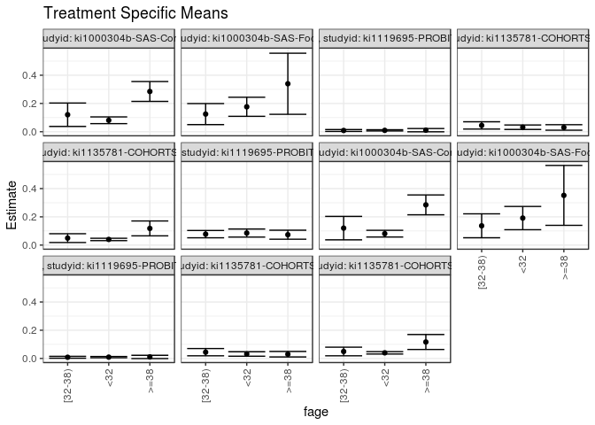

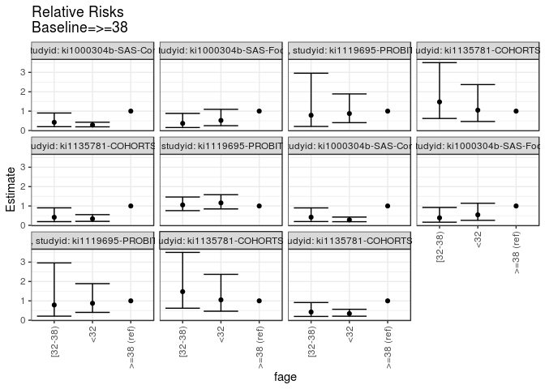

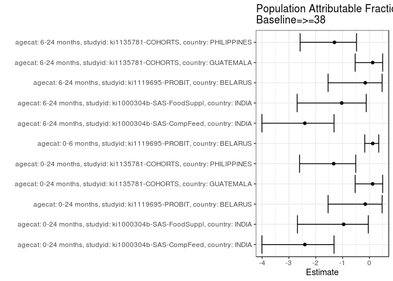

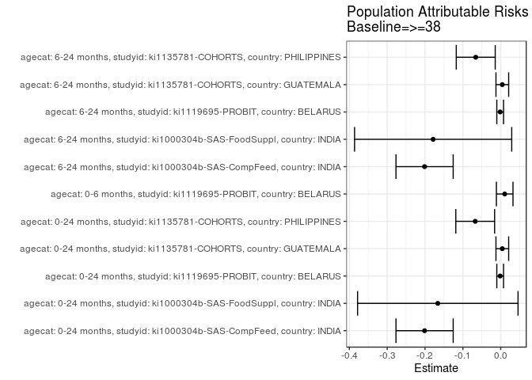

## Results Table

### Parameter: TSM

| agecat | studyid | country | intervention_level | baseline_level | estimate | ci_lower | ci_upper |
| --- | --- | --- | --- | --- | --- | --- | --- |
| 0-24 months | ki1000304b-SAS-CompFeed | INDIA | >=38 | NA | 0.2848287 | 0.2144566 | 0.3552009 |
| 0-24 months | ki1000304b-SAS-CompFeed | INDIA | <32 | NA | 0.0808534 | 0.0570246 | 0.1046822 |
| 0-24 months | ki1000304b-SAS-CompFeed | INDIA | [32-38) | NA | 0.1201942 | 0.0372484 | 0.2031401 |
| 0-24 months | ki1000304b-SAS-FoodSuppl | INDIA | >=38 | NA | 0.3395723 | 0.1232086 | 0.5559360 |
| 0-24 months | ki1000304b-SAS-FoodSuppl | INDIA | <32 | NA | 0.1764061 | 0.1089475 | 0.2438647 |
| 0-24 months | ki1000304b-SAS-FoodSuppl | INDIA | [32-38) | NA | 0.1248477 | 0.0503049 | 0.1993905 |
| 0-24 months | ki1119695-PROBIT | BELARUS | >=38 | NA | 0.0109141 | -0.0006952 | 0.0225233 |
| 0-24 months | ki1119695-PROBIT | BELARUS | <32 | NA | 0.0095335 | 0.0052504 | 0.0138166 |
| 0-24 months | ki1119695-PROBIT | BELARUS | [32-38) | NA | 0.0085890 | 0.0019106 | 0.0152673 |
| 0-24 months | ki1135781-COHORTS | GUATEMALA | >=38 | NA | 0.0302013 | 0.0107608 | 0.0496418 |
| 0-24 months | ki1135781-COHORTS | GUATEMALA | <32 | NA | 0.0317125 | 0.0159128 | 0.0475121 |
| 0-24 months | ki1135781-COHORTS | GUATEMALA | [32-38) | NA | 0.0445344 | 0.0187968 | 0.0702720 |
| 0-24 months | ki1135781-COHORTS | PHILIPPINES | >=38 | NA | 0.1180910 | 0.0653969 | 0.1707851 |
| 0-24 months | ki1135781-COHORTS | PHILIPPINES | <32 | NA | 0.0400199 | 0.0316595 | 0.0483803 |
| 0-24 months | ki1135781-COHORTS | PHILIPPINES | [32-38) | NA | 0.0492975 | 0.0182248 | 0.0803702 |
| 0-6 months | ki1119695-PROBIT | BELARUS | >=38 | NA | 0.0734707 | 0.0416422 | 0.1052992 |
| 0-6 months | ki1119695-PROBIT | BELARUS | <32 | NA | 0.0851857 | 0.0567402 | 0.1136313 |
| 0-6 months | ki1119695-PROBIT | BELARUS | [32-38) | NA | 0.0774915 | 0.0516656 | 0.1033175 |
| 6-24 months | ki1000304b-SAS-CompFeed | INDIA | >=38 | NA | 0.2848287 | 0.2144566 | 0.3552009 |
| 6-24 months | ki1000304b-SAS-CompFeed | INDIA | <32 | NA | 0.0808534 | 0.0570246 | 0.1046822 |
| 6-24 months | ki1000304b-SAS-CompFeed | INDIA | [32-38) | NA | 0.1201942 | 0.0372484 | 0.2031401 |
| 6-24 months | ki1000304b-SAS-FoodSuppl | INDIA | >=38 | NA | 0.3519007 | 0.1398553 | 0.5639460 |
| 6-24 months | ki1000304b-SAS-FoodSuppl | INDIA | <32 | NA | 0.1912696 | 0.1089788 | 0.2735603 |
| 6-24 months | ki1000304b-SAS-FoodSuppl | INDIA | [32-38) | NA | 0.1365469 | 0.0518697 | 0.2212240 |
| 6-24 months | ki1119695-PROBIT | BELARUS | >=38 | NA | 0.0109141 | -0.0006952 | 0.0225233 |
| 6-24 months | ki1119695-PROBIT | BELARUS | <32 | NA | 0.0095335 | 0.0052504 | 0.0138166 |
| 6-24 months | ki1119695-PROBIT | BELARUS | [32-38) | NA | 0.0085890 | 0.0019106 | 0.0152673 |
| 6-24 months | ki1135781-COHORTS | GUATEMALA | >=38 | NA | 0.0302013 | 0.0107608 | 0.0496418 |
| 6-24 months | ki1135781-COHORTS | GUATEMALA | <32 | NA | 0.0317125 | 0.0159128 | 0.0475121 |
| 6-24 months | ki1135781-COHORTS | GUATEMALA | [32-38) | NA | 0.0445344 | 0.0187968 | 0.0702720 |
| 6-24 months | ki1135781-COHORTS | PHILIPPINES | >=38 | NA | 0.1166703 | 0.0637598 | 0.1695808 |
| 6-24 months | ki1135781-COHORTS | PHILIPPINES | <32 | NA | 0.0399474 | 0.0315784 | 0.0483164 |
| 6-24 months | ki1135781-COHORTS | PHILIPPINES | [32-38) | NA | 0.0494565 | 0.0188824 | 0.0800307 |

### Parameter: E(Y)

| agecat | studyid | country | intervention_level | baseline_level | estimate | ci_lower | ci_upper |
| --- | --- | --- | --- | --- | --- | --- | --- |
| 0-24 months | ki1000304b-SAS-CompFeed | INDIA | NA | NA | 0.0836390 | 0.0602327 | 0.1070453 |
| 0-24 months | ki1000304b-SAS-FoodSuppl | INDIA | NA | NA | 0.1733333 | 0.1349698 | 0.2116969 |
| 0-24 months | ki1119695-PROBIT | BELARUS | NA | NA | 0.0094523 | 0.0051727 | 0.0137318 |
| 0-24 months | ki1135781-COHORTS | GUATEMALA | NA | NA | 0.0343811 | 0.0231829 | 0.0455794 |
| 0-24 months | ki1135781-COHORTS | PHILIPPINES | NA | NA | 0.0506794 | 0.0424394 | 0.0589194 |
| 0-6 months | ki1119695-PROBIT | BELARUS | NA | NA | 0.0839589 | 0.0565071 | 0.1114108 |
| 6-24 months | ki1000304b-SAS-CompFeed | INDIA | NA | NA | 0.0836390 | 0.0602327 | 0.1070453 |
| 6-24 months | ki1000304b-SAS-FoodSuppl | INDIA | NA | NA | 0.1733333 | 0.1349698 | 0.2116969 |
| 6-24 months | ki1119695-PROBIT | BELARUS | NA | NA | 0.0094523 | 0.0051727 | 0.0137318 |
| 6-24 months | ki1135781-COHORTS | GUATEMALA | NA | NA | 0.0343811 | 0.0231829 | 0.0455794 |
| 6-24 months | ki1135781-COHORTS | PHILIPPINES | NA | NA | 0.0506794 | 0.0424394 | 0.0589194 |

### Parameter: RR

| agecat | studyid | country | intervention_level | baseline_level | estimate | ci_lower | ci_upper |
| --- | --- | --- | --- | --- | --- | --- | --- |
| 0-24 months | ki1000304b-SAS-CompFeed | INDIA | >=38 | >=38 | 1.0000000 | 1.0000000 | 1.0000000 |
| 0-24 months | ki1000304b-SAS-CompFeed | INDIA | <32 | >=38 | 0.2838667 | 0.1886485 | 0.4271452 |
| 0-24 months | ki1000304b-SAS-CompFeed | INDIA | [32-38) | >=38 | 0.4219878 | 0.1974828 | 0.9017174 |
| 0-24 months | ki1000304b-SAS-FoodSuppl | INDIA | >=38 | >=38 | 1.0000000 | 1.0000000 | 1.0000000 |
| 0-24 months | ki1000304b-SAS-FoodSuppl | INDIA | <32 | >=38 | 0.5194949 | 0.2470906 | 1.0922107 |
| 0-24 months | ki1000304b-SAS-FoodSuppl | INDIA | [32-38) | >=38 | 0.3676616 | 0.1532476 | 0.8820694 |
| 0-24 months | ki1119695-PROBIT | BELARUS | >=38 | >=38 | 1.0000000 | 1.0000000 | 1.0000000 |
| 0-24 months | ki1119695-PROBIT | BELARUS | <32 | >=38 | 0.8735055 | 0.4040925 | 1.8882107 |
| 0-24 months | ki1119695-PROBIT | BELARUS | [32-38) | >=38 | 0.7869632 | 0.2094002 | 2.9575476 |
| 0-24 months | ki1135781-COHORTS | GUATEMALA | >=38 | >=38 | 1.0000000 | 1.0000000 | 1.0000000 |
| 0-24 months | ki1135781-COHORTS | GUATEMALA | <32 | >=38 | 1.0500352 | 0.4652609 | 2.3697973 |
| 0-24 months | ki1135781-COHORTS | GUATEMALA | [32-38) | >=38 | 1.4745839 | 0.6208331 | 3.5023869 |
| 0-24 months | ki1135781-COHORTS | PHILIPPINES | >=38 | >=38 | 1.0000000 | 1.0000000 | 1.0000000 |
| 0-24 months | ki1135781-COHORTS | PHILIPPINES | <32 | >=38 | 0.3388902 | 0.2070893 | 0.5545752 |
| 0-24 months | ki1135781-COHORTS | PHILIPPINES | [32-38) | >=38 | 0.4174535 | 0.1928272 | 0.9037494 |
| 0-6 months | ki1119695-PROBIT | BELARUS | >=38 | >=38 | 1.0000000 | 1.0000000 | 1.0000000 |
| 0-6 months | ki1119695-PROBIT | BELARUS | <32 | >=38 | 1.1594518 | 0.8485762 | 1.5842165 |
| 0-6 months | ki1119695-PROBIT | BELARUS | [32-38) | >=38 | 1.0547269 | 0.7605626 | 1.4626656 |
| 6-24 months | ki1000304b-SAS-CompFeed | INDIA | >=38 | >=38 | 1.0000000 | 1.0000000 | 1.0000000 |
| 6-24 months | ki1000304b-SAS-CompFeed | INDIA | <32 | >=38 | 0.2838667 | 0.1886485 | 0.4271452 |
| 6-24 months | ki1000304b-SAS-CompFeed | INDIA | [32-38) | >=38 | 0.4219878 | 0.1974828 | 0.9017174 |
| 6-24 months | ki1000304b-SAS-FoodSuppl | INDIA | >=38 | >=38 | 1.0000000 | 1.0000000 | 1.0000000 |
| 6-24 months | ki1000304b-SAS-FoodSuppl | INDIA | <32 | >=38 | 0.5435328 | 0.2591662 | 1.1399167 |
| 6-24 months | ki1000304b-SAS-FoodSuppl | INDIA | [32-38) | >=38 | 0.3880268 | 0.1629925 | 0.9237529 |
| 6-24 months | ki1119695-PROBIT | BELARUS | >=38 | >=38 | 1.0000000 | 1.0000000 | 1.0000000 |
| 6-24 months | ki1119695-PROBIT | BELARUS | <32 | >=38 | 0.8735055 | 0.4040925 | 1.8882107 |
| 6-24 months | ki1119695-PROBIT | BELARUS | [32-38) | >=38 | 0.7869632 | 0.2094002 | 2.9575476 |
| 6-24 months | ki1135781-COHORTS | GUATEMALA | >=38 | >=38 | 1.0000000 | 1.0000000 | 1.0000000 |
| 6-24 months | ki1135781-COHORTS | GUATEMALA | <32 | >=38 | 1.0500352 | 0.4652609 | 2.3697973 |
| 6-24 months | ki1135781-COHORTS | GUATEMALA | [32-38) | >=38 | 1.4745839 | 0.6208331 | 3.5023869 |
| 6-24 months | ki1135781-COHORTS | PHILIPPINES | >=38 | >=38 | 1.0000000 | 1.0000000 | 1.0000000 |
| 6-24 months | ki1135781-COHORTS | PHILIPPINES | <32 | >=38 | 0.3423956 | 0.2077887 | 0.5642016 |
| 6-24 months | ki1135781-COHORTS | PHILIPPINES | [32-38) | >=38 | 0.4238999 | 0.1968821 | 0.9126843 |

### Parameter: PAR

| agecat | studyid | country | intervention_level | baseline_level | estimate | ci_lower | ci_upper |
| --- | --- | --- | --- | --- | --- | --- | --- |
| 0-24 months | ki1000304b-SAS-CompFeed | INDIA | >=38 | NA | -0.2011897 | -0.2767774 | -0.1256020 |
| 0-24 months | ki1000304b-SAS-FoodSuppl | INDIA | >=38 | NA | -0.1662390 | -0.3782341 | 0.0457561 |
| 0-24 months | ki1119695-PROBIT | BELARUS | >=38 | NA | -0.0014618 | -0.0103666 | 0.0074430 |
| 0-24 months | ki1135781-COHORTS | GUATEMALA | >=38 | NA | 0.0041798 | -0.0126151 | 0.0209747 |
| 0-24 months | ki1135781-COHORTS | PHILIPPINES | >=38 | NA | -0.0674116 | -0.1186863 | -0.0161369 |
| 0-6 months | ki1119695-PROBIT | BELARUS | >=38 | NA | 0.0104882 | -0.0114493 | 0.0324258 |
| 6-24 months | ki1000304b-SAS-CompFeed | INDIA | >=38 | NA | -0.2011897 | -0.2767774 | -0.1256020 |
| 6-24 months | ki1000304b-SAS-FoodSuppl | INDIA | >=38 | NA | -0.1785673 | -0.3862081 | 0.0290734 |
| 6-24 months | ki1119695-PROBIT | BELARUS | >=38 | NA | -0.0014618 | -0.0103666 | 0.0074430 |
| 6-24 months | ki1135781-COHORTS | GUATEMALA | >=38 | NA | 0.0041798 | -0.0126151 | 0.0209747 |
| 6-24 months | ki1135781-COHORTS | PHILIPPINES | >=38 | NA | -0.0659909 | -0.1174569 | -0.0145249 |

### Parameter: PAF

| agecat | studyid | country | intervention_level | baseline_level | estimate | ci_lower | ci_upper |
| --- | --- | --- | --- | --- | --- | --- | --- |
| 0-24 months | ki1000304b-SAS-CompFeed | INDIA | >=38 | NA | -2.4054524 | -4.0052956 | -1.3169673 |
| 0-24 months | ki1000304b-SAS-FoodSuppl | INDIA | >=38 | NA | -0.9590711 | -2.6820721 | -0.0423369 |
| 0-24 months | ki1119695-PROBIT | BELARUS | >=38 | NA | -0.1546489 | -1.5393504 | 0.4749783 |
| 0-24 months | ki1135781-COHORTS | GUATEMALA | >=38 | NA | 0.1215724 | -0.5292244 | 0.4954076 |
| 0-24 months | ki1135781-COHORTS | PHILIPPINES | >=38 | NA | -1.3301582 | -2.6013187 | -0.5076802 |
| 0-6 months | ki1119695-PROBIT | BELARUS | >=38 | NA | 0.1249211 | -0.1736976 | 0.3475636 |
| 6-24 months | ki1000304b-SAS-CompFeed | INDIA | >=38 | NA | -2.4054524 | -4.0052956 | -1.3169673 |
| 6-24 months | ki1000304b-SAS-FoodSuppl | INDIA | >=38 | NA | -1.0301961 | -2.6919900 | -0.1163888 |
| 6-24 months | ki1119695-PROBIT | BELARUS | >=38 | NA | -0.1546489 | -1.5393504 | 0.4749783 |
| 6-24 months | ki1135781-COHORTS | GUATEMALA | >=38 | NA | 0.1215724 | -0.5292244 | 0.4954076 |
| 6-24 months | ki1135781-COHORTS | PHILIPPINES | >=38 | NA | -1.3021254 | -2.5806910 | -0.4801002 |